# Data filtering

# Depth for individual samples

We can look at the depth of coverage of various samples. This can be useful to find if a particular sample has low quality.

```r
DP <-geno(vcf)$DP
summary_dp <- DP[is.na(DP)] <- 0
long_dp <- gather(data.frame(DP),value = "DP", key="Sample")
long_dp %>%
  group_by(Sample) %>%
  summarise(
    n = n(),
    mean_DP = mean(DP, na.rm = TRUE),
    std_DP  = sd(DP, na.rm = TRUE)
  ) -> summary_dp
```

| Sample | n | mean_DP | std_DP |
| --- | --- | --- | --- |
| Fex1 | 20620 | 7.306353 | 9.729400 |
| Fex10 | 20620 | 10.898739 | 14.177238 |
| Fex11 | 20620 | 9.175849 | 13.543446 |
| Fex12 | 20620 | 12.205286 | 16.032310 |
| Fex13 | 20620 | 14.063531 | 19.484195 |
| Fex14 | 20620 | 9.818671 | 13.411106 |
| Fex15 | 20620 | 10.319981 | 13.646079 |
| Fex16 | 20620 | 13.047769 | 18.056399 |
| Fex17 | 20620 | 12.447769 | 16.089833 |
| Fex18 | 20620 | 14.220369 | 22.543101 |
| Fex19 | 20620 | 10.075412 | 14.050866 |
| Fex2 | 20620 | 12.068865 | 16.972320 |
| Fex20 | 20620 | 15.964161 | 19.647557 |
| Fex21 | 20620 | 12.637876 | 15.395132 |
| Fex22 | 20620 | 11.289137 | 15.800327 |
| Fex23 | 20620 | 11.863822 | 17.689616 |
| Fex24 | 20620 | 10.070466 | 18.857208 |
| Fex25 | 20620 | 8.327158 | 9.791787 |
| Fex26 | 20620 | 13.012221 | 17.368032 |
| Fex27 | 20620 | 10.450534 | 13.977195 |
| Fex28 | 20620 | 12.704850 | 18.177778 |
| Fex29 | 20620 | 10.298885 | 14.201916 |
| Fex3 | 20620 | 9.199466 | 12.967614 |
| Fex30 | 20620 | 10.940349 | 14.018360 |
| Fex31 | 20620 | 7.026285 | 9.781015 |
| Fex32 | 20620 | 8.080068 | 10.486800 |
| Fex33 | 20620 | 9.358584 | 11.326032 |
| Fex34 | 20620 | 10.241804 | 10.995112 |
| Fex35 | 20620 | 9.575121 | 10.794247 |
| Fex36 | 20620 | 10.823909 | 11.976831 |
| Fex37 | 20620 | 8.476285 | 10.591030 |
| Fex4 | 20620 | 9.694956 | 15.275143 |
| Fex5 | 20620 | 10.755383 | 13.830538 |
| Fex6 | 20620 | 9.284627 | 11.856945 |
| Fex7 | 20620 | 9.811930 | 12.764079 |
| Fex8 | 20620 | 8.646848 | 11.660582 |
| Fex9 | 20620 | 7.525897 | 9.669511 |

- Can you make a summary per contig?
- Can you make a summary per contig and per sample?

# Distribution across sample

You can focus on the distribution of a few samples.

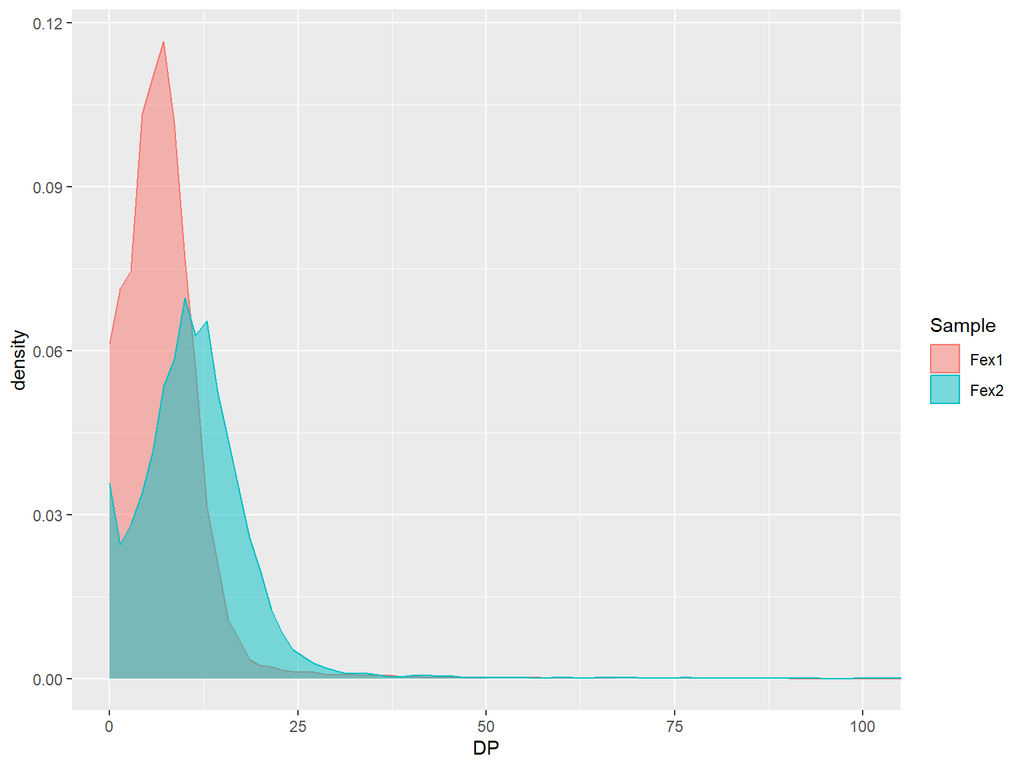

```r
long_dp %>% filter( Sample %in% c("Fex1", "Fex2")) %>%
ggplot() +
geom_density(aes(x=DP, colour=Sample, fill=Sample), alpha=0.5) +
coord_cartesian(xlim = c(0,100))
```

# Displaying all the samples

For all the samples, you can show just a boxplot,at the cost of having less resultion of the shape of the distribution

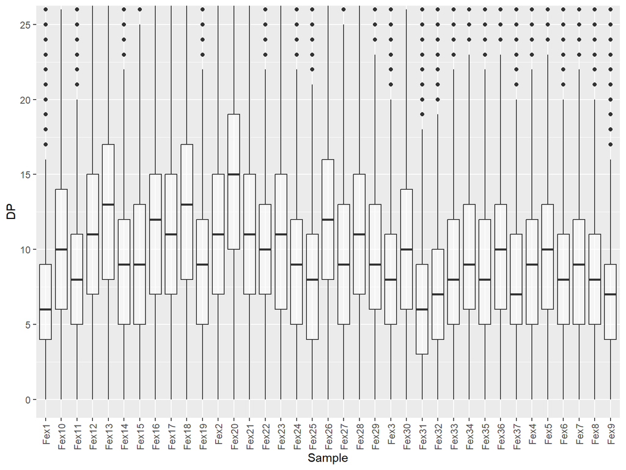

```r
long_dp %>%
ggplot() +
geom_boxplot(aes(y=DP, x=Sample), alpha=0.5) +
coord_cartesian(ylim = c(0,25)) +
theme(axis.text.x = element_text(angle = 90, vjust = 0.5, hjust=1))
```

# Questions for you

- How many `seqnames` are present?
- Plot the count of genotypes on each sequence.
- Can you calculate the allele frequency ($\frac{R0}{DP}$) for each sample? Plot 2 or 3 samples.
- Plot the distribution of several samples together (Team1: Sample Fex1-Fex5, Team 2: Fex6-Fex10, etc)
- Are there differences in in DP across different scaffolds? Try to figure out how to extract the data for a single reference.
  - Maybe directly from the `VCF` object, or exporting the DP matrix and filter by the `rowname`.
- Do you think the samples are homozygous, heterozygous or a mix of both (you can calculate the distribution of allele frequencies or look at the GT column).
- To compare all the sample, overlapping all the distributions looks messy. Plot the `DP` for all the samples. Try `geom_boxplot` and `facet_grid`. Which one you find clearer? Is there any sample that has a significant lower coverage?

# How many `seqnames` are present?

```r
seqnames(vcf)
```

```
## factor-Rle of length 20620 with 3 runs
##   Lengths:     5473     9517     5630
##   Values : Contig23 Contig1  Contig6
## Levels(3): Contig23 Contig1 Contig6
```

# Plot the count of genotypes on each sequence.

We need to produce a dataframe with the contig names and the `GT` column

```r
GT <-geno(vcf)$GT
GT <- data.frame(GT)
GT$seqnames <- data.frame(seqnames(variations))[,1]
GT %>% gather( -seqnames ,key = "Sample", value = "GT") -> long_gt

long_gt %>%
  group_by(Sample, GT, seqnames) %>%
  summarise(
    n = n(),
    GT = unique(GT, na.rm = TRUE)
  )
```

```
## # A tibble: 492 × 4
## # Groups:   Sample, GT [185]
##    Sample GT    seqnames     n
##    <chr>  <chr> <fct>    <int>
##  1 Fex1   .     Contig23   201
##  2 Fex1   .     Contig1   1322
##  3 Fex1   .     Contig6    290
##  4 Fex1   ./.   Contig1      1
##  5 Fex1   0/0   Contig23   200
##  6 Fex1   0/0   Contig1    512
##  7 Fex1   0/0   Contig6    217
##  8 Fex1   0/1   Contig23   131
##  9 Fex1   0/1   Contig1    165
## 10 Fex1   0/1   Contig6    113
## # ℹ 482 more rows
```

# Plot the count of genotypes on each sequence.

Now we can plot from the `GT` data frame and plot the counts

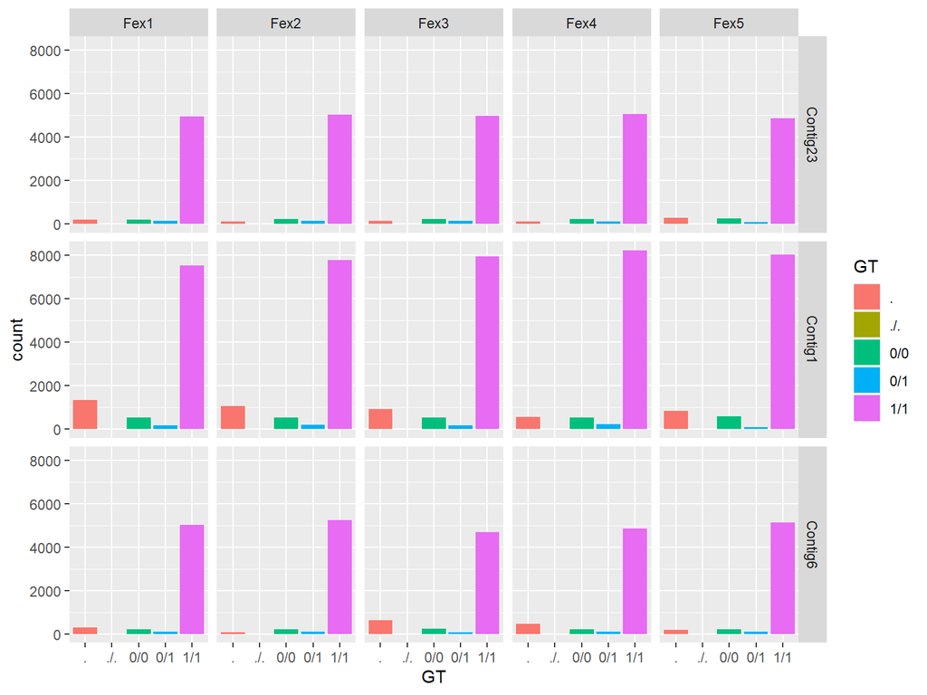

```r
 long_gt %>%
filter( Sample %in% c("Fex1", "Fex2", "Fex3", "Fex4", "Fex5")) %>%
ggplot( aes(GT, fill=GT)) + geom_bar( ) + facet_grid(seqnames~Sample)
```

# Can you calculate the allele frequency ($\frac{RO}{DP}$) for each sample? Plot 2 or 3 samples.

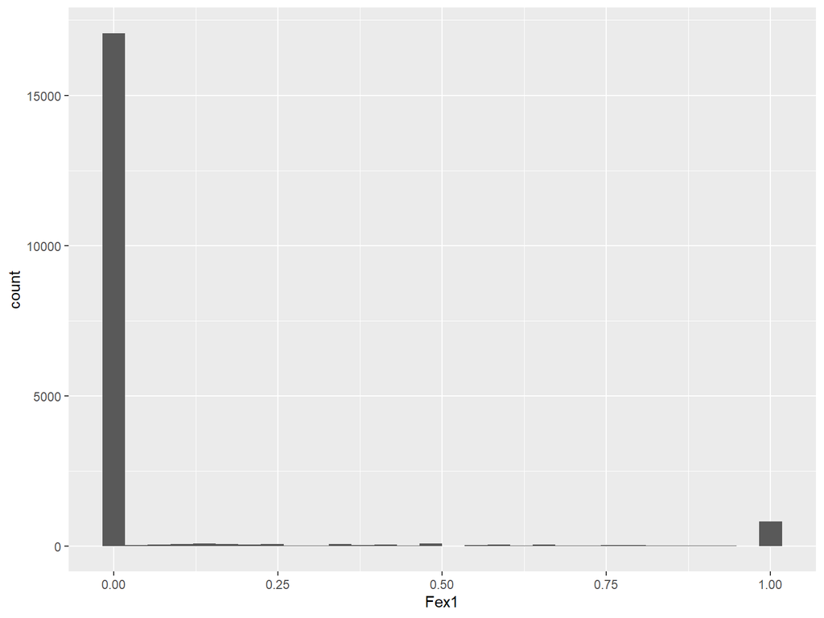

```r
DP <-geno(vcf)$DP
RO <-geno(vcf)$RO
ro_freq <- data.frame(RO/DP)

ggplot(ro_freq, aes(Fex1)) + geom_histogram()
```

# Plot the distribution of several samples together (Team1: Sample Fex1-Fex5, Team 2: Fex6-Fex10, etc)

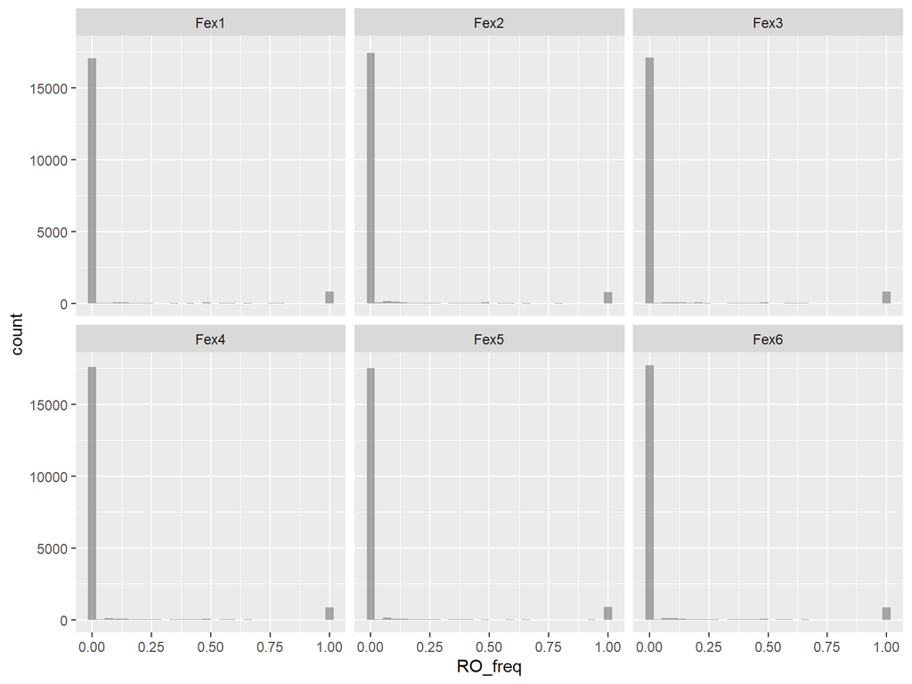

```r
long_ro_freq <- gather(ro_freq ,value = "RO_freq", key="Sample")
long_ro_freq %>% filter( Sample %in% c("Fex1", "Fex3","Fex4", "Fex2","Fex5","Fex6")) %>%
ggplot() +
geom_histogram(aes(x=RO_freq), alpha=0.5) + facet_wrap(Sample ~ .)
```

# Are there differences in in DP across different scaffolds? Try to figure out how to extract the data for a single reference.

Hint: directly from the `VCF` object, or exporting the DP matrix and filter by the `rowname`.

```r
DP <-geno(vcf)$DP
DP <- data.frame(DP)
DP$seqnames <- data.frame(seqnames(variations))[,1]
DP %>% gather(  -seqnames ,value = "DP", key="Sample") -> long_dp
```

The coverage is very similar across sequences

```r
long_dp %>%
  group_by(seqnames) %>%
  summarise(
    n = n(),
    DP = mean(DP, na.rm = TRUE)
  )
```

```
## # A tibble: 3 × 3
##   seqnames      n    DP
##   <fct>     <int> <dbl>
## 1 Contig23 202501  11.7
## 2 Contig1  352129  11.0
## 3 Contig6  208310  11.3
```

Most of the variation comes from the sample

```r
long_dp %>%
  group_by(Sample) %>%
  summarise(
    n = n(),
    DP = mean(DP, na.rm = TRUE)
  )
```

```
## # A tibble: 37 × 3
##    Sample     n    DP
##    <chr>  <int> <dbl>
##  1 Fex1   20620  8.01
##  2 Fex10  20620 11.8
##  3 Fex11  20620  9.75
##  4 Fex12  20620 12.8
##  5 Fex13  20620 14.7
##  6 Fex14  20620 10.5
##  7 Fex15  20620 11.1
##  8 Fex16  20620 13.7
##  9 Fex17  20620 13.2
## 10 Fex18  20620 14.8
## # ℹ 27 more rows
```

# To think about…

- Do you think the samples are homozygous, heterozygous or a mix of both (you can calculate the distribution of allele frequencies or look at the GT column).

The samples look homozygous, with small regions with heterozygous calls.

- To compare all the sample, overlapping all the distributions looks messy. Plot the `DP` for all the samples. Try `geom_boxplot` and `facet_grid`. Which one you find clearer? Is there any sample that has a significant lower coverage? This is a personal choice. The plots above reflect it.

# Filtering.

Based on the discussion before, using `bcftools` filger out for files with quality over 300. Read the documentation in: https://samtools.github.io/bcftools/bcftools.html#expressions to find more expression.

First simplify the VCF file to only include the GT,AO and RO files.

```bash
bcftools annotate -x "INFO,^FORMAT/GT,FORMAT/AO,Format/RO" extractedContig1.6.23.vcf.gz | bgzip -c > extractedContig1.6.23.anno.vcf.gz
```

beagle requires that even missing values correspond to the ploidy, so we need to change `.` in the genotype to `./.`

```bash
gunzip -c extractedContig1.6.23.anno.vcf.gz | sed -e 's/    \.:/    .\/.:/g' | bgzip -c >  extractedContig1.6.23.anno.fixed.vcf.gz
```

Now we can run the filtering of the formatted file

```bash
bcftools filter -e 'QUAL<300' extractedContig1.6.23.anno.fixed.vcf.gz  -O z -o extractedContig1.6.23.anno.fixed.QUAL300.vcf.gz
```

- Can you design a filter to remove only with heterozygous calls on line `Fex10`? Hint: look for `FORMAT/DP` in the documentation above.
- How does the number of heterozygous calls are affected on each line after filtering? Hint: You need to look at the GT tutorial above.

# Phasing.

We will use beagle to do the phasing and the imputing: http://faculty.washington.edu/browning/beagle/beagle.html

The documentation is here: http://faculty.washington.edu/browning/beagle/beagle_5.1_08Nov19.pdf

```bash
java -jar beagle.21Sep19.ec3.jar gt=extractedContig1.6.23.anno.fixed.QUAL300.vcf.gz  out=out.gt
```

Now, you can load `out.gt.vcf.gz` to see the results

- Do you see a change in the number of heterozygous samples?